# Assignment 5

Alexander von Humboldt

6.5.1859

```r
library(tidyverse)
library(broom)
library(magrittr)
theme_set(theme_bw())
knitr::opts_knit$set(root.dir = "C:/MSc GCG/QM/Data/data")
knitr::opts_chunk$set(message = FALSE, warning = FALSE)
```

## Does the diving time of cormorants differ with season and subspecies?

A team of researchers has tracked the seasonal diving time of two sub-species of cormorants (Phalocrocorax carbo). The sub-species are Phalocrocorax carbo carbo and Phalocrocorax carbo sinensis. You’re asked to analyze whether there are significant differences in diving time between the two sub-species, as well as between seasons.

## 1) Import and visualize the data (3 points)

Import the cormorant dataset (cormorant.txt). The dataset contains diving times (seconds) for two subspecies of Phalocrocorax carbo (subspecies carbo and sinensis). Subspecies are codes C and S. Create one boxplot of the diving times by season and one boxplot of the diving times by subspecies. The seasons are coded numerically as follows: 1 (Spring), 2 (Summer), 3 (Autumn), and 4 (Winter).

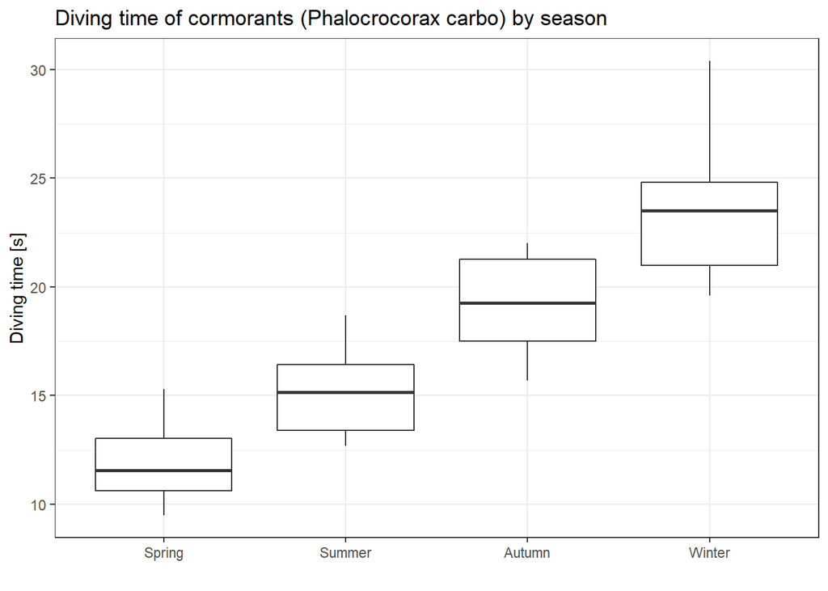

```r
cormorant <- read_csv("cormorant.txt") %>%
  mutate(across(season, ~fct_recode(as_factor(.x),
                                    Spring = "1",
                                    Summer = "2",
                                    Autumn = "3",
                                    Winter = "4")),
         across(subspecies, ~fct_recode(as_factor(.x),
                                    carbo = "C",
                                    sinensis = "S")))

ggplot(cormorant, aes(season, divingtime)) +
  geom_boxplot() +
  labs(y = "Diving time [s]",
       x = "",
       title = "Diving time of cormorants (Phalocrocorax carbo) by season")
```

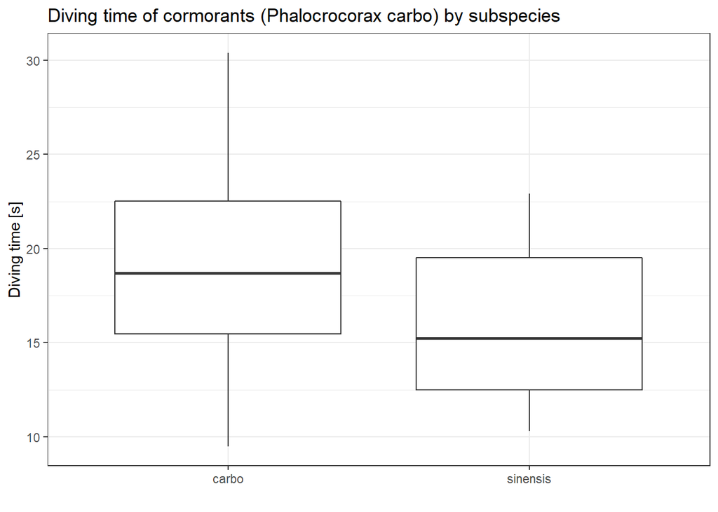

```r
ggplot(cormorant, aes(subspecies, divingtime)) +
  geom_boxplot() +
  labs(y = "Diving time [s]",
       x = "",
       title = "Diving time of cormorants (Phalocrocorax carbo) by subspecies")
```

### 2) Test for variance homogeneity. Describe your findings in one sentence. (2 points)

```r
var.test(divingtime ~ subspecies, cormorant)
```

```
##
##  F test to compare two variances
##
## data:  divingtime by subspecies
## F = 1.6625, num df = 19, denom df = 19, p-value = 0.2767
## alternative hypothesis: true ratio of variances is not equal to 1
## 95 percent confidence interval:
##  0.6580335 4.2001979
## sample estimates:
## ratio of variances
##           1.662489
```

```r
bartlett.test(divingtime ~ season, cormorant)
```

```
##
##  Bartlett test of homogeneity of variances
##
## data:  divingtime by season
## Bartlett's K-squared = 3.8345, df = 3, p-value = 0.2799
```

In both cases, the p-value is quite large, indicating that the null hypothesis of variance homogeneity cannot be rejected.

### 3) Test the significance of the effects of season and sub-species on diving time. Describe your findings in two sentences. (2 points)

```r
aov_season <- aov(divingtime ~ season, cormorant)
summary.lm(aov_season)
```

```
##
## Call:
## aov(formula = divingtime ~ season, data = cormorant)
##
## Residuals:
##    Min     1Q Median     3Q    Max
## -3.820 -1.617 -0.145  1.587  6.980
##
## Coefficients:
##              Estimate Std. Error t value Pr(>|t|)
## (Intercept)   11.8600     0.7508  15.797  < 2e-16 ***
## seasonSummer   3.2300     1.0618   3.042  0.00437 **
## seasonAutumn   7.3700     1.0618   6.941 3.92e-08 ***
## seasonWinter  11.5600     1.0618  10.887 6.11e-13 ***
## ---
## Signif. codes:  0 '***' 0.001 '**' 0.01 '*' 0.05 '.' 0.1 ' ' 1
##
## Residual standard error: 2.374 on 36 degrees of freedom
## Multiple R-squared:  0.7884, Adjusted R-squared:  0.7708
## F-statistic: 44.72 on 3 and 36 DF,  p-value: 3.156e-12
```

```r
aov_subsp <- aov(divingtime ~ subspecies, cormorant)
summary.lm(aov_subsp)
```

```
##
## Call:
## aov(formula = divingtime ~ subspecies, data = cormorant)
##
## Residuals:
##    Min     1Q Median     3Q    Max
## -9.535 -3.585 -0.335  3.760 11.365
##
## Coefficients:
##                    Estimate Std. Error t value Pr(>|t|)
## (Intercept)          19.035      1.059  17.976   <2e-16 ***
## subspeciessinensis   -3.270      1.498  -2.184   0.0352 *
## ---
## Signif. codes:  0 '***' 0.001 '**' 0.01 '*' 0.05 '.' 0.1 ' ' 1
##
## Residual standard error: 4.736 on 38 degrees of freedom
## Multiple R-squared:  0.1115, Adjusted R-squared:  0.08811
## F-statistic: 4.768 on 1 and 38 DF,  p-value: 0.03523
```

```r
aov_both <- aov(divingtime ~ subspecies + season, cormorant)
summary.lm(aov_both)
```

```
##
## Call:
## aov(formula = divingtime ~ subspecies + season, data = cormorant)
##
## Residuals:
##    Min     1Q Median     3Q    Max
## -3.995 -0.965  0.025  0.970  5.345
##
## Coefficients:
##                    Estimate Std. Error t value Pr(>|t|)
## (Intercept)         13.4950     0.5855  23.047  < 2e-16 ***
## subspeciessinensis  -3.2700     0.5237  -6.244 3.69e-07 ***
## seasonSummer         3.2300     0.7407   4.361 0.000109 ***
## seasonAutumn         7.3700     0.7407   9.951 9.65e-12 ***
## seasonWinter        11.5600     0.7407  15.608  < 2e-16 ***
## ---
## Signif. codes:  0 '***' 0.001 '**' 0.01 '*' 0.05 '.' 0.1 ' ' 1
##
## Residual standard error: 1.656 on 35 degrees of freedom
## Multiple R-squared:  0.8999, Adjusted R-squared:  0.8885
## F-statistic: 78.67 on 4 and 35 DF,  p-value: < 2.2e-16
```

```r
summary(aov_both)
```

```
##             Df Sum Sq Mean Sq F value   Pr(>F)
## subspecies   1  106.9  106.93   38.98 3.69e-07 ***
## season       3  756.2  252.06   91.89  < 2e-16 ***
## Residuals   35   96.0    2.74
## ---
## Signif. codes:  0 '***' 0.001 '**' 0.01 '*' 0.05 '.' 0.1 ' ' 1
```

Season is highly significant in both the single and multiple regression model. Subspecies is highly significant in the multiple regression model, but less significant in the single regression model.

### 4) Visually check the model assumptions (homoskedasticity and normality of residuals). Describe your findings in two sentences. (2 points)

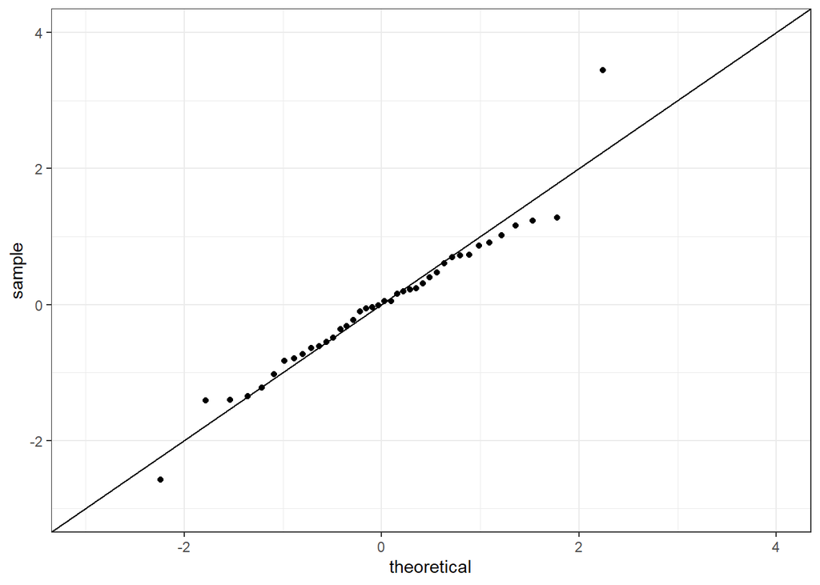

```r
aov_aug <- augment(aov_both, interval = 'confidence')
ggplot(aov_aug, aes(sample = .std.resid)) +
  stat_qq() +
  geom_abline(intercept = 0, slope = 1) +
  xlim(c(-3,4)) + ylim(c(-3,4))
```

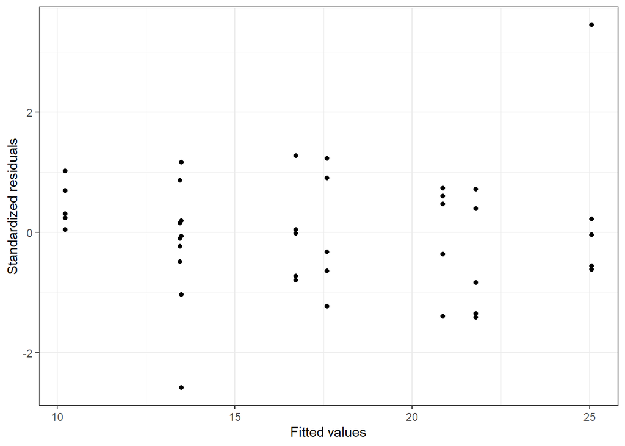

```r
ggplot(aov_aug, aes(.fitted, .std.resid)) +
  geom_point() +
  labs(x = "Fitted values",
       y = "Standardized residuals")
```

The QQ-Plot shows an outlier at the upper end, but the distribution of residuals can still be described as normal. The residuals plot shows no clear pattern, which indicates homoscedasticity.

### 5) Identify which seasons differ with respect to diving time. Conduct a multiple-comparison test to assess which seasons are significantly different from each other. Describe your findings in 1-2 sentences. (2 points)

```r
TukeyHSD(aov_season)
```

```
##   Tukey multiple comparisons of means
##     95% family-wise confidence level
##
## Fit: aov(formula = divingtime ~ season, data = cormorant)
##
## $season
##                diff       lwr      upr     p adj
## Summer-Spring  3.23 0.3703699  6.08963 0.0216909
## Autumn-Spring  7.37 4.5103699 10.22963 0.0000002
## Winter-Spring 11.56 8.7003699 14.41963 0.0000000
## Autumn-Summer  4.14 1.2803699  6.99963 0.0021923
## Winter-Summer  8.33 5.4703699 11.18963 0.0000000
## Winter-Autumn  4.19 1.3303699  7.04963 0.0019185
```

The difference between any two seasons is significant according to the p-values, with the winter to spring difference being the most pronounced.

### 6) Estimate the effect of season and subspecies. Write your findings in 2-3 sentences. (2 points)

```r
model.tables(aov_both)
```

```
## Tables of effects
##
##  subspecies
## subspecies
##    carbo sinensis
##    1.635   -1.635
##
##  season
## season
## Spring Summer Autumn Winter
##  -5.54  -2.31   1.83   6.02
```

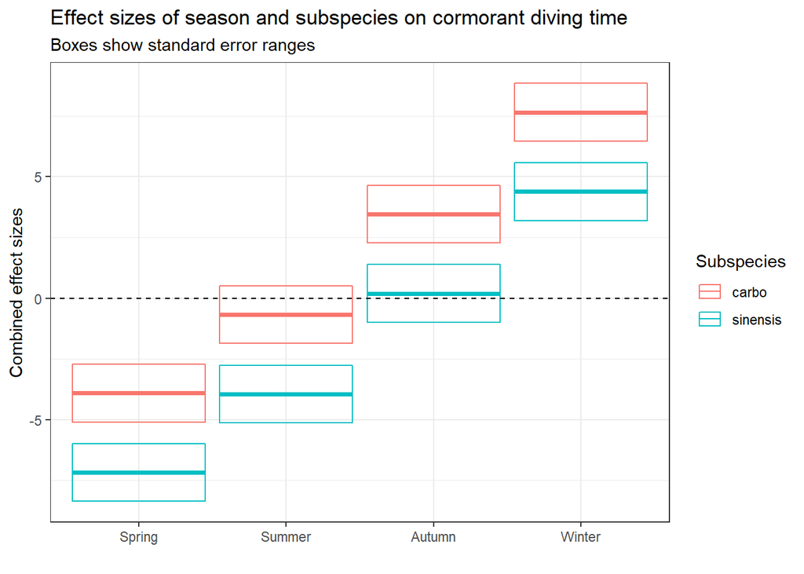

```r
# Graphical representation of combined effects
aov_aug %>%
  select(subspecies:.upper) %>%     # keeping only columns required for plotting
  distinct %>%                      # removing duplicate rows
  mutate(fx_fit = .fitted-17.4,     # demeaning data
         fx_low = .lower-17.4,
         fx_upp = .upper-17.4) %>%
  ggplot(aes(season, fx_fit,
             group = subspecies,
             col = subspecies)) +
  geom_crossbar(aes(ymin = fx_low, ymax = fx_upp)) +
  geom_hline(yintercept = 0, linetype = 2) +
  labs(x = "",
       y = "Combined effect sizes",
       color = "Subspecies",
       title = "Effect sizes of season and subspecies on cormorant diving time",
       subtitle = "Boxes show standard error ranges")
```